# Reproducible Research: Peer Assessment 1

```r
knitr::opts_chunk$set(
  fig.path = "figure/"
)
```

# Introduction

It is now possible to collect a large amount of data about personal movement using activity monitoring devices such as a [Fitbit](https://store.google.com/es/category/watches_trackers?hl=es&utm_source=fitbit_redirect&utm_medium=google_ooo&utm_campaign=category&pli=1), [Nike Fuelband](https://www.nike.com/help/a/why-cant-i-sync), or [Jawbone Up](https://www.jawbone.com/up). These type of devices are part of the “quantified self” movement – a group of enthusiasts who take measurements about themselves regularly to improve their health, to find patterns in their behavior, or because they are tech geeks. But these data remain under-utilized both because the raw data are hard to obtain and there is a lack of statistical methods and software for processing and interpreting the data.

This assignment makes use of data from a personal activity monitoring device. This device collects data at 5 minute intervals through out the day. The data consists of two months of data from an anonymous individual collected during the months of October and November, 2012 and include the number of steps taken in 5 minute intervals each day.

# Libraries

```r
library(lubridate)
library(ggplot2)
library(dplyr)
library(hrbrthemes)
library(data.table)
```

# Data

The data for this assignment can be downloaded from the course web site:

- Dataset: [Activity monitoring data](https://d396qusza40orc.cloudfront.net/repdata%2Fdata%2Factivity.zip) [52K]

The variables included in this dataset are:

- **steps**: Number of steps taking in a 5-minute interval (missing values are coded as NA)
- **date**: The date on which the measurement was taken in YYYY-MM-DD format
- **interval**: Identifier for the 5-minute interval in which measurement was taken

The dataset is stored in a comma-separated-value (CSV) file and there are a total of 17,568 observations in this dataset.

## Loading and preprocessing the data

Show any code that is needed to

Load the data (i.e. read.csv() read.csv())

Downloading and unzipping data to obtain the csv file.

```r
# Define file and directory paths
zipUrl <- "https://d396qusza40orc.cloudfront.net/repdata%2Fdata%2Factivity.zip"
zipFile <- "getdata-projectfiles-UCI HAR Dataset.zip"

# Download the zip file if it doesn't exist
if(!file.exists(zipFile)) {
        temp <- tempfile()
        download.file(zipUrl,temp)
        unzip(temp)
        unlink(temp)
}
```

Reading csv.

```r
activity_data <- read.csv("activity.csv", header=T, quote="\"", sep=",")
head(activity_data)
```

```
##   steps       date interval
## 1    NA 2012-10-01        0
## 2    NA 2012-10-01        5
## 3    NA 2012-10-01       10
## 4    NA 2012-10-01       15
## 5    NA 2012-10-01       20
## 6    NA 2012-10-01       25
```

Process/transform the data (if necessary) into a format suitable for your analysis

# What is mean total number of steps taken per day?

For this part of the assignment, you can ignore the missing values in the dataset.

1. Calculate the total number of steps taken per day

```r
totalSteps <- activity_data %>%
  group_by(date) %>%
  summarise(steps = sum(steps, na.rm = FALSE))

head(totalSteps)
```

```
## # A tibble: 6 × 2
##   date       steps
##   <chr>      <int>
## 1 2012-10-01    NA
## 2 2012-10-02   126
## 3 2012-10-03 11352
## 4 2012-10-04 12116
## 5 2012-10-05 13294
## 6 2012-10-06 15420
```

2. If you do not understand the difference between a histogram and a barplot, research the difference between them. Make a histogram of the total number of steps taken each day

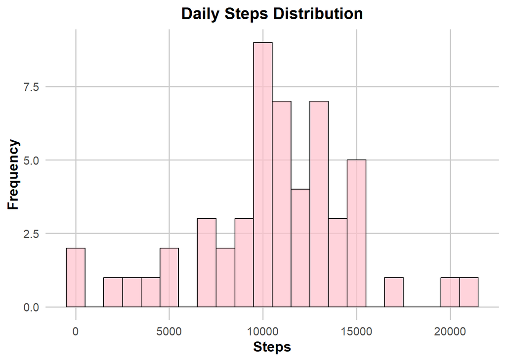

```r
ggplot(totalSteps, aes(x = steps)) +
    geom_histogram(fill = "pink", color = "black", binwidth = 1000, alpha = 0.7) +
    labs(title = "Daily Steps Distribution", x = "Steps", y = "Frequency") +
    theme_minimal(base_size = 14) +
    theme(plot.title = element_text(hjust = 0.5, face = "bold", size = 16),
          axis.title = element_text(face = "bold"),
          panel.grid.major = element_line(color = "gray80"),
          panel.grid.minor = element_blank())
```

3. Calculate and report the mean and median of the total number of steps taken per day

```r
totalSteps %>%
  summarise(
    Mean_Steps = mean(steps, na.rm = TRUE),
    Median_Steps = median(steps, na.rm = TRUE)
  )
```

```
## # A tibble: 1 × 2
##   Mean_Steps Median_Steps
##        <dbl>        <int>
## 1     10766.        10765
```

# What is the average daily activity pattern?

1. Make a time series plot (i.e. type = “l” type = “l”) of the 5-minute interval (x-axis) and the average number of steps taken, averaged across all days (y-axis)

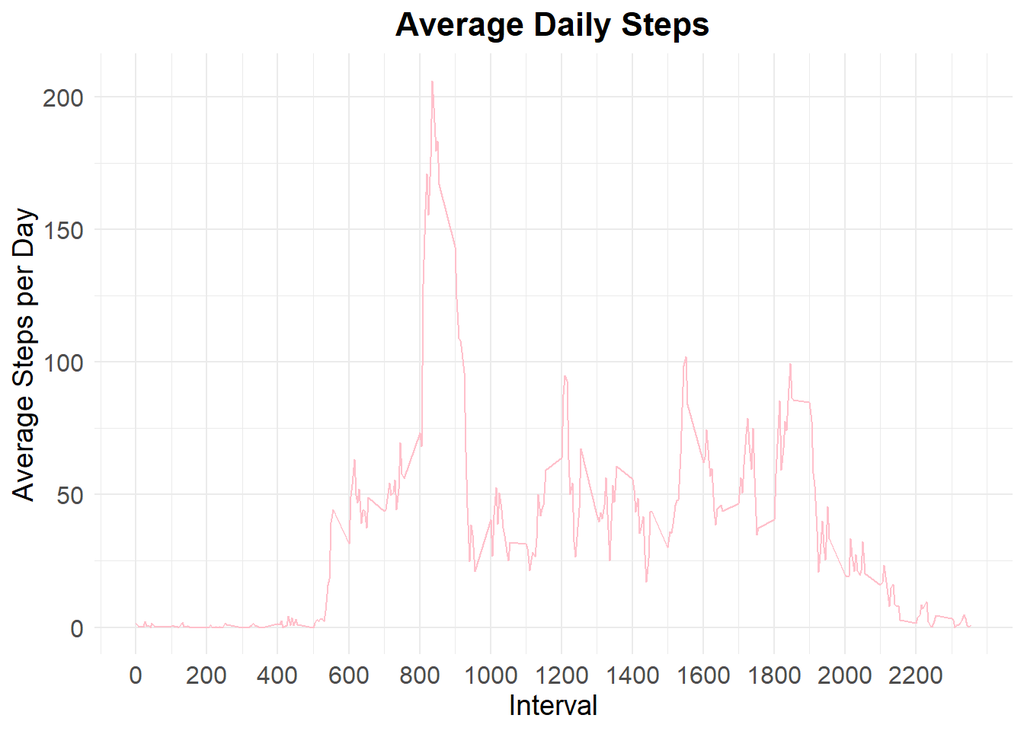

```r
intervalDT <- activity_data %>%
  group_by(interval) %>%
  summarise(steps = mean(steps, na.rm = TRUE))

ggplot(intervalDT, aes(x = interval, y = steps)) +
  geom_line(color = "pink", linewidth = 0.5) +  # linewidth en lugar de size para evitar advertencias
  labs(title = "Average Daily Steps",
       x = "Interval",
       y = "Average Steps per Day") +
  theme_minimal() +
  theme(
    plot.title = element_text(hjust = 0.5, face = "bold", size = 16),  # Título más grande y centrado
    axis.title = element_text(size = 14),  # Etiquetas de los ejes más grandes
    axis.text = element_text(size = 12)  # Números de los ejes más legibles
  ) +
  scale_x_continuous(breaks = seq(0, max(intervalDT$interval), by = 200))  # Mejora la legibilidad del eje X
```

2. Which 5-minute interval, on average across all the days in the dataset, contains the maximum number of steps?

```r
intervalDT$interval[which.max(intervalDT$steps)]
```

```
## [1] 835
```

# Imputing missing values

Note that there are a number of days/intervals where there are missing values (coded as NA NA). The presence of missing days may introduce bias into some calculations or summaries of the data.

1. Calculate and report the total number of missing values in the dataset (i.e. the total number of rows with NA NAs)

```r
sum(is.na(activity_data))
```

```
## [1] 2304
```

2. Devise a strategy for filling in all of the missing values in the dataset. The strategy does not need to be sophisticated. For example, you could use the mean/median for that day, or the mean for that 5-minute interval, etc.

```r
strategy<-activity_data %>%
  mutate(steps = ifelse(is.na(steps), median(steps, na.rm = TRUE), steps))
head(strategy)
```

```
##   steps       date interval
## 1     0 2012-10-01        0
## 2     0 2012-10-01        5
## 3     0 2012-10-01       10
## 4     0 2012-10-01       15
## 5     0 2012-10-01       20
## 6     0 2012-10-01       25
```

3. Create a new dataset that is equal to the original dataset but with the missing data filled in.

```r
# Calcular la media por intervalo
interval_means <- activity_data %>%
  group_by(interval) %>%
  summarise(mean_steps = mean(steps, na.rm = TRUE))

# Imputar valores faltantes usando la media por intervalo
activity_data_filled <- activity_data %>%
  left_join(interval_means, by = "interval") %>%
  mutate(
    steps_imputed = ifelse(is.na(steps), TRUE, FALSE),  # Marcar si es imputado
    steps = ifelse(is.na(steps), mean_steps, steps)     # Imputar valores
  ) %>%
  select(-mean_steps)
```

4. Make a histogram of the total number of steps taken each day and Calculate and report the mean and median total number of steps taken per day. Do these values differ from the estimates from the first part of the assignment? What is the impact of imputing missing data on the estimates of the total daily number of steps?

```r
# Check the number of zeros in the original dataset before and after imputation
sum(activity_data$steps == 0, na.rm = TRUE)          # Before imputation
```

```
## [1] 11014
```

```r
sum(activity_data_filled$steps == 0, na.rm = TRUE)   # After imputation
```

```
## [1] 11166
```

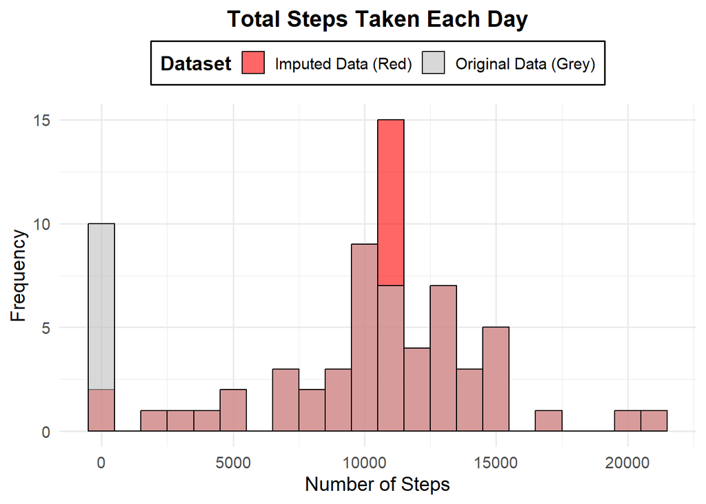

```r
# Calculate total steps per day, and flag if imputation occurred for any steps on that day
total_steps_per_day_filled <- activity_data_filled %>%
  group_by(date) %>%
  summarise(
    total_steps = sum(steps, na.rm = TRUE),
    imputed = any(steps_imputed)  # TRUE if there was at least one imputed value
  )

# Calculate total steps per day for both original and imputed datasets
total_steps_original <- activity_data %>%
  group_by(date) %>%
  summarise(total_steps = sum(steps, na.rm = TRUE), .groups = 'drop') %>%
  mutate(dataset = "Original Data")  # Label for the legend

total_steps_imputed <- activity_data_filled %>%
  group_by(date) %>%
  summarise(total_steps = sum(steps), .groups = 'drop') %>%
  mutate(dataset = "Imputed Data")  # Label for the legend

# Combine both datasets for plotting
combined_data <- bind_rows(total_steps_original, total_steps_imputed)

# Create an overlaid histogram comparing total steps per day before and after imputing missing data
ggplot(combined_data, aes(x = total_steps, fill = dataset)) +
  geom_histogram(position = "identity", color = "black", binwidth = 1000, alpha = 0.6) +

  # Customize the legend
  scale_fill_manual(
    values = c("Original Data" = "grey", "Imputed Data" = "red"),
    name = "Dataset",  # Legend title
    labels = c( "Imputed Data (Red)", "Original Data (Grey)")
  ) +

  # Titles and axis labels
  labs(
    title = "Total Steps Taken Each Day",
    x = "Number of Steps",
    y = "Frequency"
  ) +

  # Visual theme
  theme_minimal(base_size = 14) +
  theme(
    plot.title = element_text(hjust = 0.5, face = "bold", size = 16),
    legend.title = element_text(face = "bold"),
    legend.position = "top",  # Place legend at the top of the plot
    legend.background = element_rect(fill = "white", color = "black")
  )
```

```r
# Calculate the mean and median of total steps per day (after imputing)
mean_steps_filled <- mean(total_steps_per_day_filled$total_steps, na.rm = TRUE)
median_steps_filled <- median(total_steps_per_day_filled$total_steps, na.rm = TRUE)

# Print the results (after imputing)
mean_steps_filled
```

```
## [1] 10766.19
```

```r
median_steps_filled
```

```
## [1] 10766.19
```

# Are there differences in activity patterns between weekdays and weekends?

For this part the weekdays() weekdays() function may be of some help here. Use the dataset with the filled-in missing values for this part.

1. Create a new factor variable in the dataset with two levels – “weekday” and “weekend” indicating whether a given date is a weekday or weekend day.

```r
activity_data_filled <- activity_data_filled %>%
  mutate(date = as.Date(date))  # Convert the 'date' column to a Date object
# Set the locale to "C" so that weekdays() returns English names
Sys.setlocale("LC_TIME", "C")
```

```
## [1] "C"
```

```r
# Create a new variable "day_type" with levels "weekday" and "weekend"
activity_data_filled <- activity_data_filled %>%
  mutate(day_type = ifelse(weekdays(date) %in% c("Saturday", "Sunday"), "weekend", "weekday"))
```

2. Make a panel plot containing a time series plot (i.e. type = “l” type = “l”) of the 5-minute interval (x-axis) and the average number of steps taken, averaged across all weekday days or weekend days (y-axis). See the README file in the GitHub repository to see an example of what this plot should look like using simulated data.

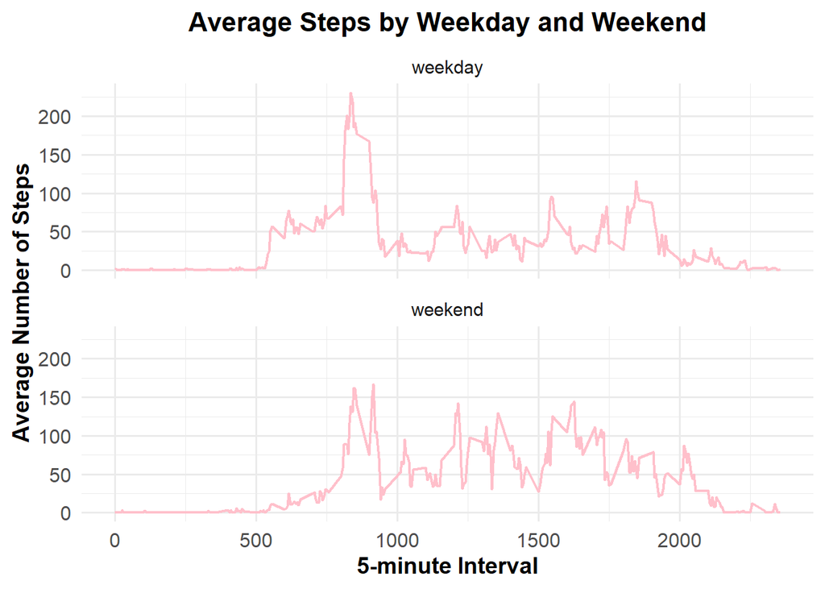

```r
# Calculate the average number of steps for each 5-minute interval, grouped by day_type
avg_steps_by_day_type <- activity_data_filled %>%
  group_by(day_type, interval) %>%
  summarise(avg_steps = mean(steps, na.rm = TRUE), .groups = "drop")

# Create the panel plot using ggplot2
ggplot(avg_steps_by_day_type, aes(x = interval, y = avg_steps)) +
  geom_line(color = "pink", linewidth = 0.8) +
  facet_wrap(~day_type, ncol = 1) +
  labs(title = "Average Steps by Weekday and Weekend",
       x = "5-minute Interval",
       y = "Average Number of Steps") +
  theme_minimal(base_size = 14) +
  theme(
    plot.title = element_text(hjust = 0.5, face = "bold", size = 16),
    axis.title = element_text(face = "bold"),
    axis.text = element_text(size = 12)
  )
```